# Are we more civilized today?

Andreas E. Mikkelsen og Lea Skriver Hansen

30/11/2021

This exercise is based on the dataset provided by [OurWorldInData project](https://ourworldindata.org/homicides) based at the Oxford University.

## The long-term trend in Homicides in Western Europe

Understanding how homicide rates have changed prior to the modern era requires the help of historians and archivists. Manuel Eisner, a criminology professor at the University of Cambridge, and his colleagues published the Historical Violence Database a compilation of data on long-term trends in homicide rates, in addition to qualitative information such as the cause of death, perpetrator and victim. This database is limited to countries with relatively complete historical records on violence and crime – mainly Western Europe and the US.

Starting in the second half of the nineteenth century, these European regions have consistent police records of those accused of murder or manslaughter and annual counts of homicide victims. To go back further in time, reaching as far back as the thirteenth century, Eisner collected estimates (from historical records of coroner reports, court trials, and the police) of homicide rates made in over ninety publications by scholars.5

In the chart shown here we see long-run homicide rates for the five European regions.

Homicide rates – measured as the number of homicides per 100,000 individuals – up to 1990 are sourced from Eisner’s (2003) publication and the Historical Violence Database. These estimates have been combined, from 1990 onwards, with homicide rates from the Global Burden of Disease study.6

In the 1300s, homicide rates in Western Europe ranged from 23 to 56 homicides per 100,000 individuals, comparable to the current rates in Latin America. Homicide rates then fell dramatically in all five regions from the 1300s to 1800s. The magnitude of this decline was similar across countries: homicide rates fell between 78 and 98%.

Homicide rates in Europe today are much lower than in the past. England, Germany, Switzerland, and Italy reached their lowest levels in the 2000s; while the Netherlands, Belgium, and Scandinavia reached their minimums in the mid to late 1900s.

```r
library(tidyverse)
```

## Load the available data from ourworldindata.org

You should always interrogate the source of your data. Who compiled it, from where, what is missing, how representative the data are? Check the data/Metadata document to learn about the data provenance.

```r
Western_Europe <- read_csv("data/homicide-rates-across-western-europe.csv")
```

## Inspect the data

How clean and analysis-ready is the dataset? Do you understand what the column names represent? What is the difference between rate and homicide number?

```r
head(Western_Europe)
```

```
## # A tibble: 6 x 4
##   Entity  Code   Year `Homicide rate in Europe over long-term (per 100,000) (ho~
##   <chr>   <chr> <dbl>                                                      <dbl>
## 1 England <NA>   1300                                                         23
## 2 England <NA>   1550                                                          7
## 3 England <NA>   1625                                                          6
## 4 England <NA>   1675                                                          4
## 5 England <NA>   1725                                                          2
## 6 England <NA>   1775                                                          1
```

Now, that you have looked at what the data looks like and what it represents, let’s see what big picture it contains.

## Let’s see what the long-term trend is in homicides

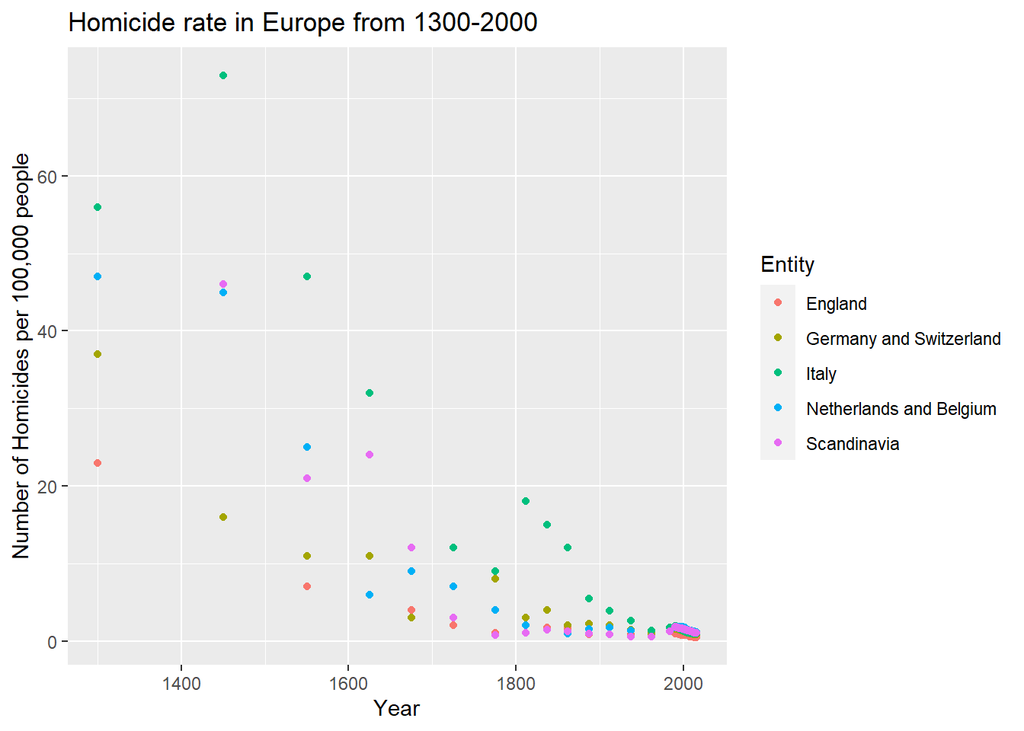

```r
ggplot(data = Western_Europe) +
  geom_point(mapping = aes(x = Year,
                           y = Western_Europe$`Homicide rate in Europe over long-term (per 100,000) (homicides per 100,000 people)`,
                           color = Entity)) +
  labs(x = "Year",
       y = "Number of Homicides per 100,000 people",
       title = "Homicide rate in Europe from 1300-2000")
```

Alright, the homicide rates are all descending over time. What a comfort. But the viz is not super clear. Let’s check the rates for individual countries.

## Let’s uncouple the homicides for easier view of individual countries

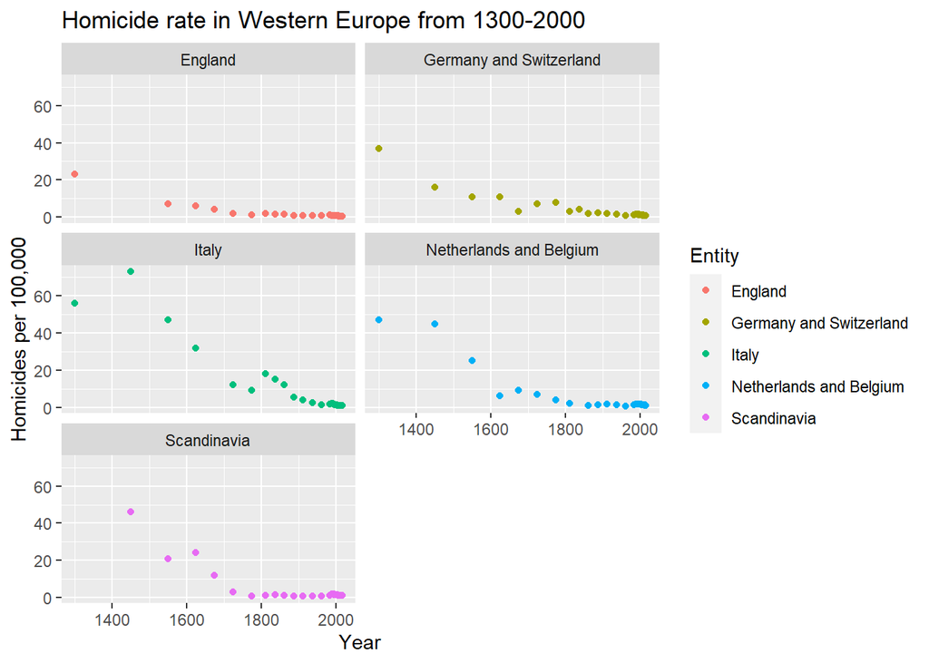

```r
ggplot(data = Western_Europe) +
  geom_point(mapping = aes(x = Year,
                           y = Western_Europe$`Homicide rate in Europe over long-term (per 100,000) (homicides per 100,000 people)`,
                           color = Entity)) +
  facet_wrap(~ Entity, nrow = 3) +
  labs(x = "Year",
       y = "Homicides per 100,000",
       title = "Homicide rate in Western Europe from 1300-2000")
```

## Let’s cross-check the trends in homicide with the pattern of reign duration among Danish rulers through time

## task 1

```r
# YOUR CODE HERE:
#task 1
 New_Western_Europe <- rename(Western_Europe, homicides_per_100k =`Homicide rate in Europe over long-term (per 100,000) (homicides per 100,000 people)`)
```

## task 2

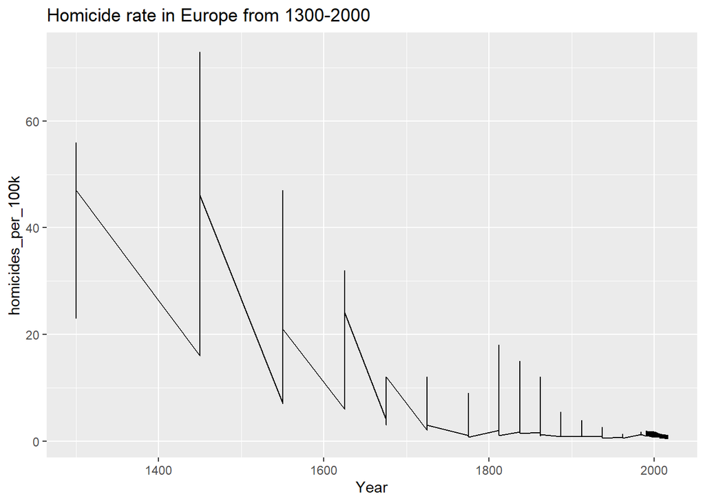

```r
#task 2
ggplot(data = New_Western_Europe) +
  geom_line(mapping = aes(x = Year,
                           y = homicides_per_100k)) +
  labs(x = "Year",
       y = "homicides_per_100k",
       title = "Homicide rate in Europe from 1300-2000")
```

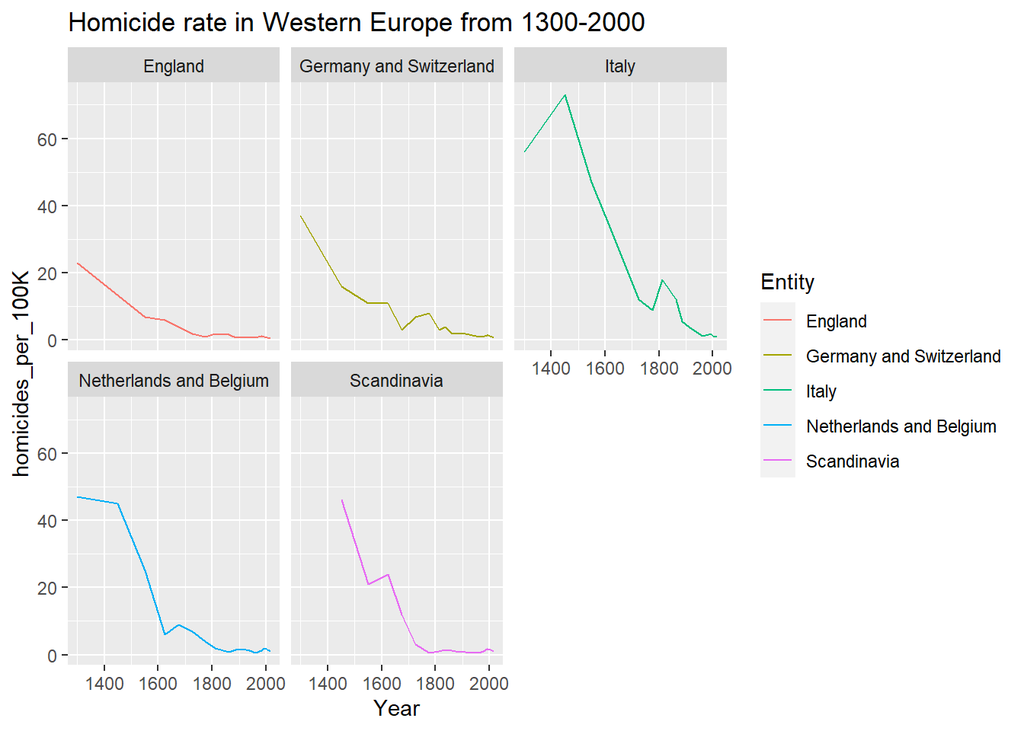

```r
#second try, first one gave a single graph and not separate
ggplot(data = New_Western_Europe) +
  geom_line(mapping = aes(x = Year,
                           y = New_Western_Europe$homicides_per_100k,
                           color = Entity)) +
  facet_wrap(~ Entity, nrow = 2) +
  labs(x = "Year",
       y = "homicides_per_100K",
       title = "Homicide rate in Western Europe from 1300-2000")
```

##task 3

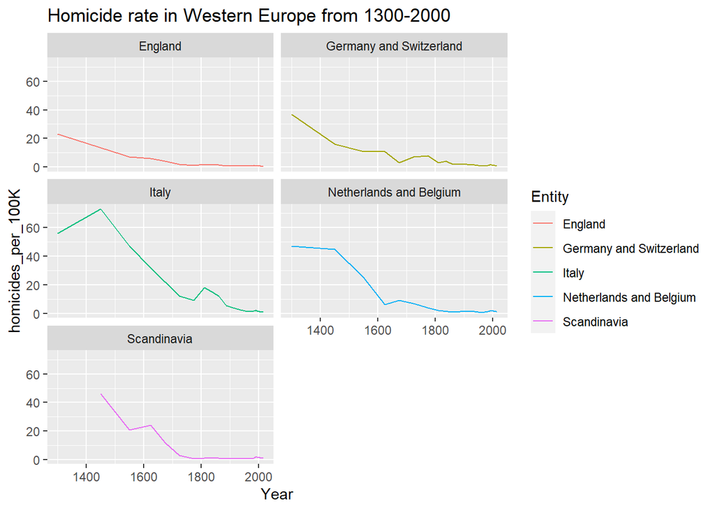

```r
#task 3
ggplot(data = New_Western_Europe) +
  geom_line(mapping = aes(x = Year,
                           y = New_Western_Europe$homicides_per_100k,
                           color = Entity)) +
  facet_wrap(~ Entity, nrow = 3) +
  labs(x = "Year",
       y = "homicides_per_100K",
       title = "Homicide rate in Western Europe from 1300-2000")
```

##task 4

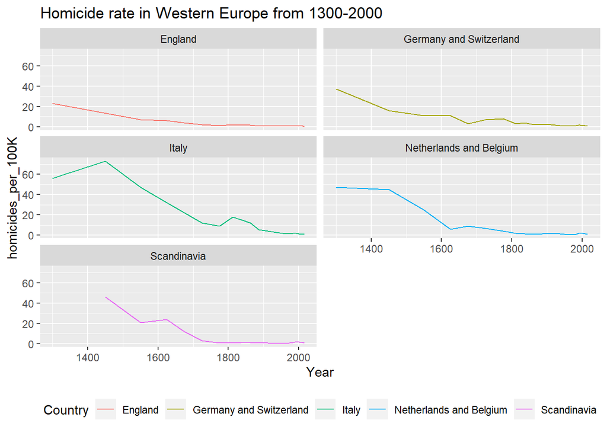

```r
#task 4
New_Western_Europe2 <- rename(New_Western_Europe, Country =`Entity`)

ggplot(data = New_Western_Europe2) +
  geom_line(mapping = aes(x = Year,
                           y = New_Western_Europe2$homicides_per_100k,
                           color = Country)) +
  theme(legend.position="bottom") +
  facet_wrap(~ Country, nrow = 3) +
  labs(x = "Year",
       y = "homicides_per_100K",
       title = "Homicide rate in Western Europe from 1300-2000")
```

##task 5

```r
#task 5
# can be found in the YAML
```

##task 6

```r
getwd()
```

```
## [1] "C:/Users/aemik/OneDrive/Skrivebord/digital metode/HomicideHistory-main"
```

```r
konger <- read_csv2("./data/KongerækkeDK.csv",na = c("NA","N/A"))
```

```
## i Using "','" as decimal and "'.'" as grouping mark. Use `read_delim()` for more control.
```

```
## * `` -> ...1
```

```r
  konger2 <- konger %>%
  mutate(midyear = konger$Reign_End - (konger$Reign_End-konger$Reign_Start)/2)  # creating midyear column
```

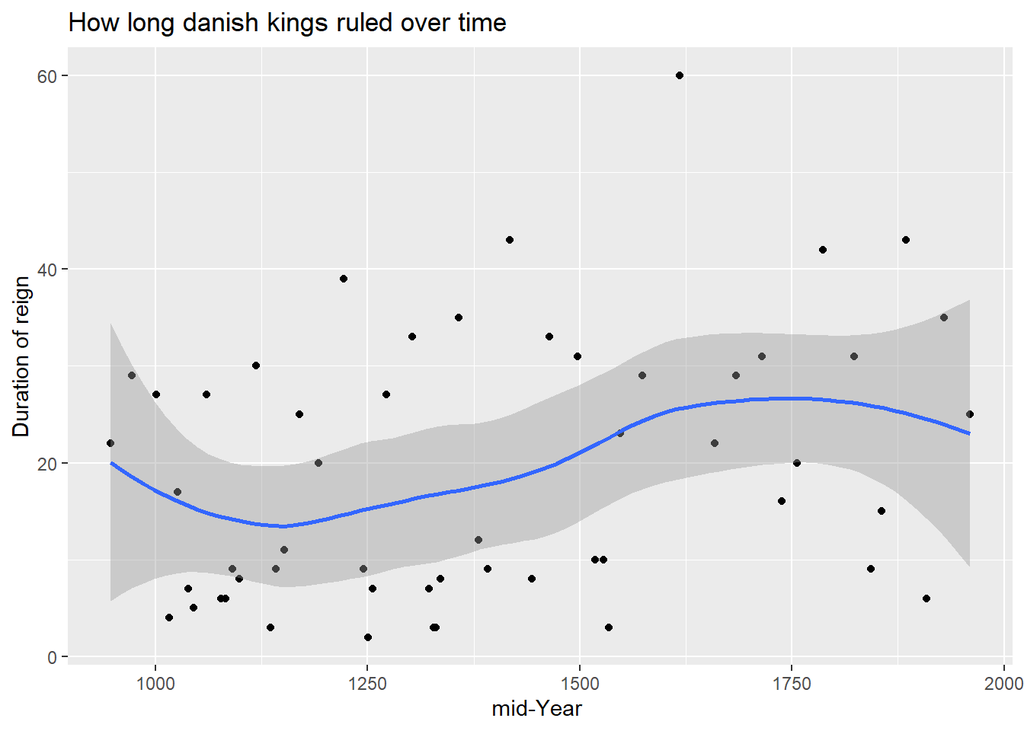

```r
ggplot(konger2, aes(x = midyear, y = konger2$Reign_Total_Year)) +
  geom_point()+
  geom_smooth()+
  labs(title = "How long danish kings ruled over time",
       x = "mid-Year ", y = "Duration of reign")
```

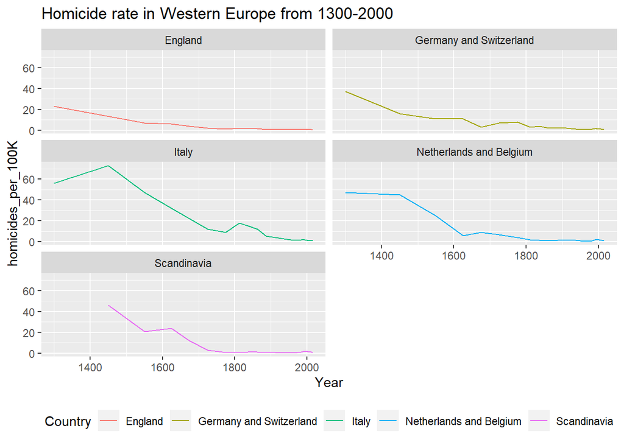

```r
ggplot(data = New_Western_Europe2) +
  geom_line(mapping = aes(x = Year,
                           y = New_Western_Europe2$homicides_per_100k,
                           color = Country)) +
  theme(legend.position="bottom") +
  facet_wrap(~ Country, nrow = 3) +
  labs(x = "Year",
       y = "homicides_per_100K",
       title = "Homicide rate in Western Europe from 1300-2000")
```

## task 7

is hard to comment anything only by this, there are a fair few facts this does bot show us. If we only focus on this data, it would seem like we have stopped killing each other as much and the kings somewhat rule longer than before, but not by much.

**Your Tasks:**

1. the column name Western_Europe$`Homicide rate in Europe over long-term (per 100,000) is not very easy to work with. Relabel it to ‘homicides_per_100k’ inside R after loading the dataset and then edit all the ggplots.
2. The basic plot and following facet-plot (combination plot) is great, but geom_point - a scatterplot - is not the best choice for showing long-term data. Can you change both plots to more suitable type of rendering?
3. Can you change the facet “layout” to two columns and three rows so that the trends are easier to see?
4. Move the legend from the current position on the side to below the facets, and label it “Country” instead of “Entity”.
5. Add a floating table of contents to your Rmarkdown document, provide informative chunk-names to all your R chunks, and automatically generate a timestamp to show when the document was last updated. (Hint: check the Rmarkdown episode in our Data Carpentry tutorial)
6. Fill in the empty code chunk with a ggplot of your Danish kings: loading the data, calculating the mid-year, and plotting the duration of reign (y axis) over the mid-year (x axis), using geom_smooth()
7. Comment briefly what is your opinion on the basis of the data visualisations: are we more civilized today?